# Risk Factor Analysis

## Outcome Variable

**Outcome Variable:** ever_swasted

## Predictor Variables

**Intervention Variable:** mbmi

**Adjustment Set:**

- arm
- W_mage
- meducyrs
- feducyrs
- hhwealth_quart
- W_nchldlt5
- brthmon
- W_parity
- delta_W_mage
- delta_meducyrs
- delta_feducyrs
- delta_hhwealth_quart
- delta_W_nchldlt5
- delta_brthmon
- delta_W_parity

## Stratifying Variables

The analysis was stratified on these variable(s):

- agecat
- studyid
- country

## Data Summary

| agecat | studyid | country | mbmi | ever_swasted | n_cell | n |
| --- | --- | --- | --- | --- | --- | --- |
| 0-24 months | iLiNS-Zinc | BURKINA FASO | Normal weight | 0 | 2647 | 3217 |
| 0-24 months | iLiNS-Zinc | BURKINA FASO | Normal weight | 1 | 116 | 3217 |
| 0-24 months | iLiNS-Zinc | BURKINA FASO | Underweight | 0 | 416 | 3217 |
| 0-24 months | iLiNS-Zinc | BURKINA FASO | Underweight | 1 | 38 | 3217 |
| 0-24 months | JiVitA-3 | BANGLADESH | Normal weight | 0 | 15561 | 26836 |
| 0-24 months | JiVitA-3 | BANGLADESH | Normal weight | 1 | 999 | 26836 |
| 0-24 months | JiVitA-3 | BANGLADESH | Underweight | 0 | 9638 | 26836 |
| 0-24 months | JiVitA-3 | BANGLADESH | Underweight | 1 | 638 | 26836 |
| 0-24 months | LCNI-5 | MALAWI | Normal weight | 0 | 686 | 837 |
| 0-24 months | LCNI-5 | MALAWI | Normal weight | 1 | 6 | 837 |
| 0-24 months | LCNI-5 | MALAWI | Underweight | 0 | 143 | 837 |
| 0-24 months | LCNI-5 | MALAWI | Underweight | 1 | 2 | 837 |
| 0-24 months | MAL-ED | BANGLADESH | Normal weight | 0 | 209 | 254 |
| 0-24 months | MAL-ED | BANGLADESH | Normal weight | 1 | 13 | 254 |
| 0-24 months | MAL-ED | BANGLADESH | Underweight | 0 | 24 | 254 |
| 0-24 months | MAL-ED | BANGLADESH | Underweight | 1 | 8 | 254 |
| 0-24 months | MAL-ED | BRAZIL | Normal weight | 0 | 207 | 221 |
| 0-24 months | MAL-ED | BRAZIL | Normal weight | 1 | 4 | 221 |
| 0-24 months | MAL-ED | BRAZIL | Underweight | 0 | 10 | 221 |
| 0-24 months | MAL-ED | BRAZIL | Underweight | 1 | 0 | 221 |
| 0-24 months | MAL-ED | INDIA | Normal weight | 0 | 175 | 242 |
| 0-24 months | MAL-ED | INDIA | Normal weight | 1 | 18 | 242 |
| 0-24 months | MAL-ED | INDIA | Underweight | 0 | 41 | 242 |
| 0-24 months | MAL-ED | INDIA | Underweight | 1 | 8 | 242 |
| 0-24 months | MAL-ED | NEPAL | Normal weight | 0 | 229 | 238 |
| 0-24 months | MAL-ED | NEPAL | Normal weight | 1 | 9 | 238 |
| 0-24 months | MAL-ED | NEPAL | Underweight | 0 | 0 | 238 |
| 0-24 months | MAL-ED | NEPAL | Underweight | 1 | 0 | 238 |
| 0-24 months | MAL-ED | PERU | Normal weight | 0 | 281 | 290 |
| 0-24 months | MAL-ED | PERU | Normal weight | 1 | 4 | 290 |

[output cut: 170 more lines]

The following strata were considered:

- agecat: 0-24 months, studyid: iLiNS-Zinc, country: BURKINA FASO
- agecat: 0-24 months, studyid: JiVitA-3, country: BANGLADESH
- agecat: 0-24 months, studyid: LCNI-5, country: MALAWI
- agecat: 0-24 months, studyid: MAL-ED, country: BANGLADESH
- agecat: 0-24 months, studyid: MAL-ED, country: BRAZIL
- agecat: 0-24 months, studyid: MAL-ED, country: INDIA
- agecat: 0-24 months, studyid: MAL-ED, country: NEPAL
- agecat: 0-24 months, studyid: MAL-ED, country: PERU
- agecat: 0-24 months, studyid: MAL-ED, country: SOUTH AFRICA
- agecat: 0-24 months, studyid: MAL-ED, country: TANZANIA, UNITED REPUBLIC OF
- agecat: 0-24 months, studyid: NIH-Birth, country: BANGLADESH
- agecat: 0-24 months, studyid: NIH-Crypto, country: BANGLADESH
- agecat: 0-24 months, studyid: PROBIT, country: BELARUS
- agecat: 0-24 months, studyid: PROVIDE, country: BANGLADESH
- agecat: 0-24 months, studyid: SAS-CompFeed, country: INDIA
- agecat: 0-24 months, studyid: TanzaniaChild2, country: TANZANIA, UNITED REPUBLIC OF
- agecat: 0-24 months, studyid: ZVITAMBO, country: ZIMBABWE
- agecat: 0-6 months, studyid: JiVitA-3, country: BANGLADESH
- agecat: 0-6 months, studyid: LCNI-5, country: MALAWI
- agecat: 0-6 months, studyid: MAL-ED, country: BANGLADESH
- agecat: 0-6 months, studyid: MAL-ED, country: BRAZIL
- agecat: 0-6 months, studyid: MAL-ED, country: INDIA
- agecat: 0-6 months, studyid: MAL-ED, country: NEPAL
- agecat: 0-6 months, studyid: MAL-ED, country: PERU
- agecat: 0-6 months, studyid: MAL-ED, country: SOUTH AFRICA
- agecat: 0-6 months, studyid: MAL-ED, country: TANZANIA, UNITED REPUBLIC OF
- agecat: 0-6 months, studyid: NIH-Birth, country: BANGLADESH
- agecat: 0-6 months, studyid: NIH-Crypto, country: BANGLADESH
- agecat: 0-6 months, studyid: PROBIT, country: BELARUS
- agecat: 0-6 months, studyid: PROVIDE, country: BANGLADESH
- agecat: 0-6 months, studyid: SAS-CompFeed, country: INDIA
- agecat: 0-6 months, studyid: TanzaniaChild2, country: TANZANIA, UNITED REPUBLIC OF
- agecat: 0-6 months, studyid: ZVITAMBO, country: ZIMBABWE
- agecat: 6-24 months, studyid: iLiNS-Zinc, country: BURKINA FASO
- agecat: 6-24 months, studyid: JiVitA-3, country: BANGLADESH
- agecat: 6-24 months, studyid: LCNI-5, country: MALAWI
- agecat: 6-24 months, studyid: MAL-ED, country: BANGLADESH
- agecat: 6-24 months, studyid: MAL-ED, country: BRAZIL
- agecat: 6-24 months, studyid: MAL-ED, country: INDIA
- agecat: 6-24 months, studyid: MAL-ED, country: NEPAL
- agecat: 6-24 months, studyid: MAL-ED, country: PERU
- agecat: 6-24 months, studyid: MAL-ED, country: SOUTH AFRICA
- agecat: 6-24 months, studyid: MAL-ED, country: TANZANIA, UNITED REPUBLIC OF
- agecat: 6-24 months, studyid: NIH-Birth, country: BANGLADESH
- agecat: 6-24 months, studyid: NIH-Crypto, country: BANGLADESH
- agecat: 6-24 months, studyid: PROBIT, country: BELARUS
- agecat: 6-24 months, studyid: PROVIDE, country: BANGLADESH
- agecat: 6-24 months, studyid: SAS-CompFeed, country: INDIA
- agecat: 6-24 months, studyid: TanzaniaChild2, country: TANZANIA, UNITED REPUBLIC OF
- agecat: 6-24 months, studyid: ZVITAMBO, country: ZIMBABWE

### Dropped Strata

Some strata were dropped due to rare outcomes:

- agecat: 0-24 months, studyid: LCNI-5, country: MALAWI
- agecat: 0-24 months, studyid: MAL-ED, country: BRAZIL
- agecat: 0-24 months, studyid: MAL-ED, country: NEPAL
- agecat: 0-24 months, studyid: MAL-ED, country: PERU
- agecat: 0-24 months, studyid: MAL-ED, country: SOUTH AFRICA
- agecat: 0-24 months, studyid: MAL-ED, country: TANZANIA, UNITED REPUBLIC OF
- agecat: 0-24 months, studyid: TanzaniaChild2, country: TANZANIA, UNITED REPUBLIC OF
- agecat: 0-6 months, studyid: LCNI-5, country: MALAWI
- agecat: 0-6 months, studyid: MAL-ED, country: BRAZIL
- agecat: 0-6 months, studyid: MAL-ED, country: NEPAL
- agecat: 0-6 months, studyid: MAL-ED, country: PERU
- agecat: 0-6 months, studyid: MAL-ED, country: SOUTH AFRICA
- agecat: 0-6 months, studyid: MAL-ED, country: TANZANIA, UNITED REPUBLIC OF
- agecat: 0-6 months, studyid: TanzaniaChild2, country: TANZANIA, UNITED REPUBLIC OF
- agecat: 6-24 months, studyid: LCNI-5, country: MALAWI
- agecat: 6-24 months, studyid: MAL-ED, country: BANGLADESH
- agecat: 6-24 months, studyid: MAL-ED, country: BRAZIL
- agecat: 6-24 months, studyid: MAL-ED, country: INDIA
- agecat: 6-24 months, studyid: MAL-ED, country: NEPAL
- agecat: 6-24 months, studyid: MAL-ED, country: PERU
- agecat: 6-24 months, studyid: MAL-ED, country: SOUTH AFRICA
- agecat: 6-24 months, studyid: MAL-ED, country: TANZANIA, UNITED REPUBLIC OF
- agecat: 6-24 months, studyid: PROBIT, country: BELARUS
- agecat: 6-24 months, studyid: PROVIDE, country: BANGLADESH
- agecat: 6-24 months, studyid: TanzaniaChild2, country: TANZANIA, UNITED REPUBLIC OF

## Methods Detail

We’re interested in the causal parameters $E[Y_a]$ for all values of $a \in \mathcal{A}$. These parameters represent the mean outcome if, possibly contrary to fact, we intervened to set all units to have $A=a$. Under the randomization and positivity assumptions, these are identified by the statistical parameters $\psi_a=E_W[E_{Y|A,W}(Y|A=a,W)]$. In addition, we’re interested in the mean of $Y$, $E[Y]$ under no intervention (the observed mean). We will estimate these parameters by using SuperLearner to fit the relevant likelihood factors – $E_{Y|A,W}(Y|A=a,W)$ and $p(A=a|W)$, and then updating our likelihood fit using a joint TMLE.

For unadjusted analyses ($W=\{\}$), initial likelihoods were estimated using Lrnr_glm to estimate the simple $E(Y|A)$ and Lrnr_mean to estimate $p(A)$. For adjusted analyses, a small library containing Lrnr_glmnet, Lrnr_xgboost, and Lrnr_mean was used.

Having estimated these parameters, we will then use the delta method to estimate relative risks and attributable risks relative to a prespecified baseline level of $A$.

# Results Detail

## Results Plots

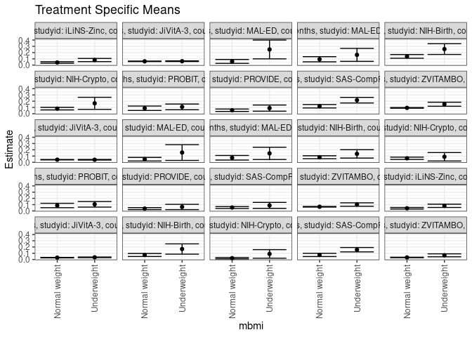

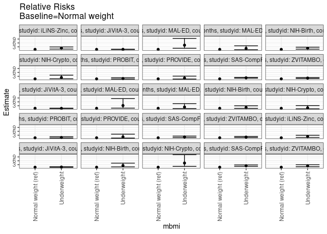

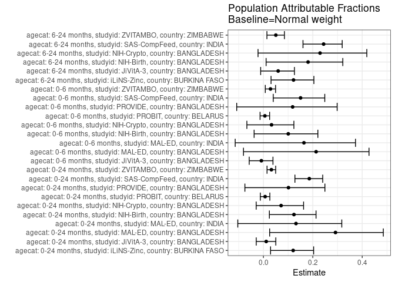

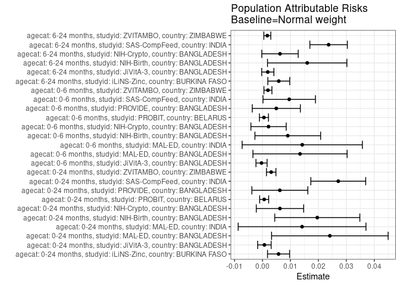

## Results Table

### Parameter: TSM

| agecat | studyid | country | intervention_level | baseline_level | estimate | ci_lower | ci_upper |
| --- | --- | --- | --- | --- | --- | --- | --- |
| 0-24 months | iLiNS-Zinc | BURKINA FASO | Normal weight | NA | 0.0421032 | 0.0296101 | 0.0545962 |
| 0-24 months | iLiNS-Zinc | BURKINA FASO | Underweight | NA | 0.0807495 | 0.0553598 | 0.1061392 |
| 0-24 months | JiVitA-3 | BANGLADESH | Normal weight | NA | 0.0603048 | 0.0561429 | 0.0644666 |
| 0-24 months | JiVitA-3 | BANGLADESH | Underweight | NA | 0.0621490 | 0.0567753 | 0.0675227 |
| 0-24 months | MAL-ED | BANGLADESH | Normal weight | NA | 0.0585586 | 0.0276115 | 0.0895057 |
| 0-24 months | MAL-ED | BANGLADESH | Underweight | NA | 0.2500000 | 0.0996753 | 0.4003247 |
| 0-24 months | MAL-ED | INDIA | Normal weight | NA | 0.0932642 | 0.0521524 | 0.1343761 |
| 0-24 months | MAL-ED | INDIA | Underweight | NA | 0.1632653 | 0.0595626 | 0.2669680 |
| 0-24 months | NIH-Birth | BANGLADESH | Normal weight | NA | 0.1390352 | 0.1092582 | 0.1688122 |
| 0-24 months | NIH-Birth | BANGLADESH | Underweight | NA | 0.2560766 | 0.1699578 | 0.3421954 |
| 0-24 months | NIH-Crypto | BANGLADESH | Normal weight | NA | 0.0811557 | 0.0605282 | 0.1017833 |
| 0-24 months | NIH-Crypto | BANGLADESH | Underweight | NA | 0.1657756 | 0.0692364 | 0.2623148 |
| 0-24 months | PROBIT | BELARUS | Normal weight | NA | 0.0871634 | 0.0519807 | 0.1223461 |
| 0-24 months | PROBIT | BELARUS | Underweight | NA | 0.1086782 | 0.0632632 | 0.1540933 |
| 0-24 months | PROVIDE | BANGLADESH | Normal weight | NA | 0.0550692 | 0.0358531 | 0.0742853 |
| 0-24 months | PROVIDE | BANGLADESH | Underweight | NA | 0.0894300 | 0.0402635 | 0.1385966 |
| 0-24 months | SAS-CompFeed | INDIA | Normal weight | NA | 0.1189158 | 0.0915960 | 0.1462356 |
| 0-24 months | SAS-CompFeed | INDIA | Underweight | NA | 0.2161168 | 0.1712915 | 0.2609421 |
| 0-24 months | ZVITAMBO | ZIMBABWE | Normal weight | NA | 0.0933374 | 0.0874136 | 0.0992612 |
| 0-24 months | ZVITAMBO | ZIMBABWE | Underweight | NA | 0.1512911 | 0.1192415 | 0.1833407 |
| 0-6 months | JiVitA-3 | BANGLADESH | Normal weight | NA | 0.0417033 | 0.0382135 | 0.0451930 |
| 0-6 months | JiVitA-3 | BANGLADESH | Underweight | NA | 0.0408941 | 0.0363772 | 0.0454111 |
| 0-6 months | MAL-ED | BANGLADESH | Normal weight | NA | 0.0495495 | 0.0209465 | 0.0781526 |
| 0-6 months | MAL-ED | BANGLADESH | Underweight | NA | 0.1562500 | 0.0301989 | 0.2823011 |
| 0-6 months | MAL-ED | INDIA | Normal weight | NA | 0.0725389 | 0.0358696 | 0.1092081 |
| 0-6 months | MAL-ED | INDIA | Underweight | NA | 0.1428571 | 0.0446763 | 0.2410380 |
| 0-6 months | NIH-Birth | BANGLADESH | Normal weight | NA | 0.0809711 | 0.0574765 | 0.1044657 |
| 0-6 months | NIH-Birth | BANGLADESH | Underweight | NA | 0.1349399 | 0.0678226 | 0.2020572 |
| 0-6 months | NIH-Crypto | BANGLADESH | Normal weight | NA | 0.0640466 | 0.0457263 | 0.0823669 |
| 0-6 months | NIH-Crypto | BANGLADESH | Underweight | NA | 0.0882353 | 0.0207757 | 0.1556949 |
| 0-6 months | PROBIT | BELARUS | Normal weight | NA | 0.0865951 | 0.0513938 | 0.1217963 |
| 0-6 months | PROBIT | BELARUS | Underweight | NA | 0.1054229 | 0.0610459 | 0.1497999 |
| 0-6 months | PROVIDE | BANGLADESH | Normal weight | NA | 0.0369004 | 0.0210177 | 0.0527831 |
| 0-6 months | PROVIDE | BANGLADESH | Underweight | NA | 0.0629921 | 0.0207072 | 0.1052771 |
| 0-6 months | SAS-CompFeed | INDIA | Normal weight | NA | 0.0540559 | 0.0387643 | 0.0693475 |
| 0-6 months | SAS-CompFeed | INDIA | Underweight | NA | 0.0881782 | 0.0403059 | 0.1360506 |
| 0-6 months | ZVITAMBO | ZIMBABWE | Normal weight | NA | 0.0663827 | 0.0613061 | 0.0714594 |
| 0-6 months | ZVITAMBO | ZIMBABWE | Underweight | NA | 0.1016795 | 0.0745235 | 0.1288355 |
| 6-24 months | iLiNS-Zinc | BURKINA FASO | Normal weight | NA | 0.0420336 | 0.0295506 | 0.0545166 |
| 6-24 months | iLiNS-Zinc | BURKINA FASO | Underweight | NA | 0.0813617 | 0.0549080 | 0.1078153 |
| 6-24 months | JiVitA-3 | BANGLADESH | Normal weight | NA | 0.0299866 | 0.0265438 | 0.0334294 |
| 6-24 months | JiVitA-3 | BANGLADESH | Underweight | NA | 0.0349459 | 0.0301511 | 0.0397408 |
| 6-24 months | NIH-Birth | BANGLADESH | Normal weight | NA | 0.0725534 | 0.0482645 | 0.0968423 |
| 6-24 months | NIH-Birth | BANGLADESH | Underweight | NA | 0.1676411 | 0.0853009 | 0.2499813 |
| 6-24 months | NIH-Crypto | BANGLADESH | Normal weight | NA | 0.0211161 | 0.0101649 | 0.0320673 |
| 6-24 months | NIH-Crypto | BANGLADESH | Underweight | NA | 0.0895522 | 0.0211337 | 0.1579708 |
| 6-24 months | SAS-CompFeed | INDIA | Normal weight | NA | 0.0734335 | 0.0475471 | 0.0993200 |
| 6-24 months | SAS-CompFeed | INDIA | Underweight | NA | 0.1568144 | 0.1220109 | 0.1916179 |
| 6-24 months | ZVITAMBO | ZIMBABWE | Normal weight | NA | 0.0328087 | 0.0289360 | 0.0366813 |
| 6-24 months | ZVITAMBO | ZIMBABWE | Underweight | NA | 0.0669167 | 0.0434304 | 0.0904030 |

### Parameter: E(Y)

| agecat | studyid | country | intervention_level | baseline_level | estimate | ci_lower | ci_upper |
| --- | --- | --- | --- | --- | --- | --- | --- |
| 0-24 months | iLiNS-Zinc | BURKINA FASO | NA | NA | 0.0478707 | 0.0359037 | 0.0598376 |
| 0-24 months | JiVitA-3 | BANGLADESH | NA | NA | 0.0610001 | 0.0575046 | 0.0644957 |
| 0-24 months | MAL-ED | BANGLADESH | NA | NA | 0.0826772 | 0.0487426 | 0.1166117 |
| 0-24 months | MAL-ED | INDIA | NA | NA | 0.1074380 | 0.0683415 | 0.1465345 |
| 0-24 months | NIH-Birth | BANGLADESH | NA | NA | 0.1586538 | 0.1299648 | 0.1873429 |
| 0-24 months | NIH-Crypto | BANGLADESH | NA | NA | 0.0874172 | 0.0672569 | 0.1075775 |
| 0-24 months | PROBIT | BELARUS | NA | NA | 0.0877768 | 0.0530196 | 0.1225340 |
| 0-24 months | PROVIDE | BANGLADESH | NA | NA | 0.0612855 | 0.0430966 | 0.0794744 |
| 0-24 months | SAS-CompFeed | INDIA | NA | NA | 0.1460432 | 0.1145875 | 0.1774988 |
| 0-24 months | ZVITAMBO | ZIMBABWE | NA | NA | 0.0964581 | 0.0906120 | 0.1023042 |
| 0-6 months | JiVitA-3 | BANGLADESH | NA | NA | 0.0413628 | 0.0383754 | 0.0443502 |
| 0-6 months | MAL-ED | BANGLADESH | NA | NA | 0.0629921 | 0.0330555 | 0.0929287 |
| 0-6 months | MAL-ED | INDIA | NA | NA | 0.0867769 | 0.0512358 | 0.1223179 |
| 0-6 months | NIH-Birth | BANGLADESH | NA | NA | 0.0900322 | 0.0675202 | 0.1125442 |
| 0-6 months | NIH-Crypto | BANGLADESH | NA | NA | 0.0662252 | 0.0484753 | 0.0839750 |
| 0-6 months | PROBIT | BELARUS | NA | NA | 0.0871212 | 0.0523702 | 0.1218722 |
| 0-6 months | PROVIDE | BANGLADESH | NA | NA | 0.0418535 | 0.0266676 | 0.0570395 |
| 0-6 months | SAS-CompFeed | INDIA | NA | NA | 0.0636298 | 0.0408673 | 0.0863923 |
| 0-6 months | ZVITAMBO | ZIMBABWE | NA | NA | 0.0683402 | 0.0633339 | 0.0733464 |
| 6-24 months | iLiNS-Zinc | BURKINA FASO | NA | NA | 0.0478707 | 0.0359037 | 0.0598376 |
| 6-24 months | JiVitA-3 | BANGLADESH | NA | NA | 0.0318915 | 0.0289933 | 0.0347896 |
| 6-24 months | NIH-Birth | BANGLADESH | NA | NA | 0.0885609 | 0.0646203 | 0.1125014 |
| 6-24 months | NIH-Crypto | BANGLADESH | NA | NA | 0.0273973 | 0.0155476 | 0.0392469 |
| 6-24 months | SAS-CompFeed | INDIA | NA | NA | 0.0971026 | 0.0697212 | 0.1244840 |
| 6-24 months | ZVITAMBO | ZIMBABWE | NA | NA | 0.0345469 | 0.0306862 | 0.0384077 |

### Parameter: RR

| agecat | studyid | country | intervention_level | baseline_level | estimate | ci_lower | ci_upper |
| --- | --- | --- | --- | --- | --- | --- | --- |
| 0-24 months | iLiNS-Zinc | BURKINA FASO | Normal weight | Normal weight | 1.0000000 | 1.0000000 | 1.000000 |
| 0-24 months | iLiNS-Zinc | BURKINA FASO | Underweight | Normal weight | 1.9178948 | 1.2751869 | 2.884534 |
| 0-24 months | JiVitA-3 | BANGLADESH | Normal weight | Normal weight | 1.0000000 | 1.0000000 | 1.000000 |
| 0-24 months | JiVitA-3 | BANGLADESH | Underweight | Normal weight | 1.0305825 | 0.9300820 | 1.141943 |
| 0-24 months | MAL-ED | BANGLADESH | Normal weight | Normal weight | 1.0000000 | 1.0000000 | 1.000000 |
| 0-24 months | MAL-ED | BANGLADESH | Underweight | Normal weight | 4.2692308 | 1.9172672 | 9.506412 |
| 0-24 months | MAL-ED | INDIA | Normal weight | Normal weight | 1.0000000 | 1.0000000 | 1.000000 |
| 0-24 months | MAL-ED | INDIA | Underweight | Normal weight | 1.7505669 | 0.8079836 | 3.792756 |
| 0-24 months | NIH-Birth | BANGLADESH | Normal weight | Normal weight | 1.0000000 | 1.0000000 | 1.000000 |
| 0-24 months | NIH-Birth | BANGLADESH | Underweight | Normal weight | 1.8418116 | 1.2371539 | 2.741995 |
| 0-24 months | NIH-Crypto | BANGLADESH | Normal weight | Normal weight | 1.0000000 | 1.0000000 | 1.000000 |
| 0-24 months | NIH-Crypto | BANGLADESH | Underweight | Normal weight | 2.0426851 | 1.0810429 | 3.859757 |
| 0-24 months | PROBIT | BELARUS | Normal weight | Normal weight | 1.0000000 | 1.0000000 | 1.000000 |
| 0-24 months | PROBIT | BELARUS | Underweight | Normal weight | 1.2468336 | 0.8293532 | 1.874466 |
| 0-24 months | PROVIDE | BANGLADESH | Normal weight | Normal weight | 1.0000000 | 1.0000000 | 1.000000 |
| 0-24 months | PROVIDE | BANGLADESH | Underweight | Normal weight | 1.6239579 | 0.8466592 | 3.114877 |
| 0-24 months | SAS-CompFeed | INDIA | Normal weight | Normal weight | 1.0000000 | 1.0000000 | 1.000000 |
| 0-24 months | SAS-CompFeed | INDIA | Underweight | Normal weight | 1.8173940 | 1.5221159 | 2.169954 |
| 0-24 months | ZVITAMBO | ZIMBABWE | Normal weight | Normal weight | 1.0000000 | 1.0000000 | 1.000000 |
| 0-24 months | ZVITAMBO | ZIMBABWE | Underweight | Normal weight | 1.6209055 | 1.2993058 | 2.022106 |
| 0-6 months | JiVitA-3 | BANGLADESH | Normal weight | Normal weight | 1.0000000 | 1.0000000 | 1.000000 |
| 0-6 months | JiVitA-3 | BANGLADESH | Underweight | Normal weight | 0.9805968 | 0.8645324 | 1.112243 |
| 0-6 months | MAL-ED | BANGLADESH | Normal weight | Normal weight | 1.0000000 | 1.0000000 | 1.000000 |
| 0-6 months | MAL-ED | BANGLADESH | Underweight | Normal weight | 3.1534091 | 1.1694063 | 8.503450 |
| 0-6 months | MAL-ED | INDIA | Normal weight | Normal weight | 1.0000000 | 1.0000000 | 1.000000 |
| 0-6 months | MAL-ED | INDIA | Underweight | Normal weight | 1.9693878 | 0.8390927 | 4.622240 |
| 0-6 months | NIH-Birth | BANGLADESH | Normal weight | Normal weight | 1.0000000 | 1.0000000 | 1.000000 |
| 0-6 months | NIH-Birth | BANGLADESH | Underweight | Normal weight | 1.6665193 | 0.9367362 | 2.964854 |
| 0-6 months | NIH-Crypto | BANGLADESH | Normal weight | Normal weight | 1.0000000 | 1.0000000 | 1.000000 |
| 0-6 months | NIH-Crypto | BANGLADESH | Underweight | Normal weight | 1.3776738 | 0.6090195 | 3.116460 |
| 0-6 months | PROBIT | BELARUS | Normal weight | Normal weight | 1.0000000 | 1.0000000 | 1.000000 |
| 0-6 months | PROBIT | BELARUS | Underweight | Normal weight | 1.2174239 | 0.8109761 | 1.827576 |
| 0-6 months | PROVIDE | BANGLADESH | Normal weight | Normal weight | 1.0000000 | 1.0000000 | 1.000000 |
| 0-6 months | PROVIDE | BANGLADESH | Underweight | Normal weight | 1.7070866 | 0.7690289 | 3.789382 |
| 0-6 months | SAS-CompFeed | INDIA | Normal weight | Normal weight | 1.0000000 | 1.0000000 | 1.000000 |
| 0-6 months | SAS-CompFeed | INDIA | Underweight | Normal weight | 1.6312417 | 1.1645433 | 2.284972 |
| 0-6 months | ZVITAMBO | ZIMBABWE | Normal weight | Normal weight | 1.0000000 | 1.0000000 | 1.000000 |
| 0-6 months | ZVITAMBO | ZIMBABWE | Underweight | Normal weight | 1.5317164 | 1.1600996 | 2.022374 |
| 6-24 months | iLiNS-Zinc | BURKINA FASO | Normal weight | Normal weight | 1.0000000 | 1.0000000 | 1.000000 |
| 6-24 months | iLiNS-Zinc | BURKINA FASO | Underweight | Normal weight | 1.9356338 | 1.2676760 | 2.955549 |
| 6-24 months | JiVitA-3 | BANGLADESH | Normal weight | Normal weight | 1.0000000 | 1.0000000 | 1.000000 |
| 6-24 months | JiVitA-3 | BANGLADESH | Underweight | Normal weight | 1.1653851 | 0.9803946 | 1.385282 |
| 6-24 months | NIH-Birth | BANGLADESH | Normal weight | Normal weight | 1.0000000 | 1.0000000 | 1.000000 |
| 6-24 months | NIH-Birth | BANGLADESH | Underweight | Normal weight | 2.3105883 | 1.2763267 | 4.182956 |
| 6-24 months | NIH-Crypto | BANGLADESH | Normal weight | Normal weight | 1.0000000 | 1.0000000 | 1.000000 |
| 6-24 months | NIH-Crypto | BANGLADESH | Underweight | Normal weight | 4.2409382 | 1.6843541 | 10.678014 |
| 6-24 months | SAS-CompFeed | INDIA | Normal weight | Normal weight | 1.0000000 | 1.0000000 | 1.000000 |
| 6-24 months | SAS-CompFeed | INDIA | Underweight | Normal weight | 2.1354602 | 1.6400299 | 2.780553 |
| 6-24 months | ZVITAMBO | ZIMBABWE | Normal weight | Normal weight | 1.0000000 | 1.0000000 | 1.000000 |
| 6-24 months | ZVITAMBO | ZIMBABWE | Underweight | Normal weight | 2.0396055 | 1.4083686 | 2.953766 |

### Parameter: PAR

| agecat | studyid | country | intervention_level | baseline_level | estimate | ci_lower | ci_upper |
| --- | --- | --- | --- | --- | --- | --- | --- |
| 0-24 months | iLiNS-Zinc | BURKINA FASO | Normal weight | NA | 0.0057675 | 0.0018166 | 0.0097184 |
| 0-24 months | JiVitA-3 | BANGLADESH | Normal weight | NA | 0.0006954 | -0.0017235 | 0.0031143 |
| 0-24 months | MAL-ED | BANGLADESH | Normal weight | NA | 0.0241186 | 0.0032585 | 0.0449787 |
| 0-24 months | MAL-ED | INDIA | Normal weight | NA | 0.0141738 | -0.0086912 | 0.0370388 |
| 0-24 months | NIH-Birth | BANGLADESH | Normal weight | NA | 0.0196187 | 0.0043915 | 0.0348459 |
| 0-24 months | NIH-Crypto | BANGLADESH | Normal weight | NA | 0.0062615 | -0.0022111 | 0.0147340 |
| 0-24 months | PROBIT | BELARUS | Normal weight | NA | 0.0006134 | -0.0010014 | 0.0022283 |
| 0-24 months | PROVIDE | BANGLADESH | Normal weight | NA | 0.0062163 | -0.0037994 | 0.0162321 |
| 0-24 months | SAS-CompFeed | INDIA | Normal weight | NA | 0.0271274 | 0.0173108 | 0.0369440 |
| 0-24 months | ZVITAMBO | ZIMBABWE | Normal weight | NA | 0.0031207 | 0.0014285 | 0.0048129 |
| 0-6 months | JiVitA-3 | BANGLADESH | Normal weight | NA | -0.0003405 | -0.0023271 | 0.0016461 |
| 0-6 months | MAL-ED | BANGLADESH | Normal weight | NA | 0.0134426 | -0.0034159 | 0.0303011 |
| 0-6 months | MAL-ED | INDIA | Normal weight | NA | 0.0142380 | -0.0072807 | 0.0357567 |
| 0-6 months | NIH-Birth | BANGLADESH | Normal weight | NA | 0.0090611 | -0.0026933 | 0.0208154 |
| 0-6 months | NIH-Crypto | BANGLADESH | Normal weight | NA | 0.0021786 | -0.0041367 | 0.0084939 |
| 0-6 months | PROBIT | BELARUS | Normal weight | NA | 0.0005261 | -0.0010943 | 0.0021466 |
| 0-6 months | PROVIDE | BANGLADESH | Normal weight | NA | 0.0049531 | -0.0036567 | 0.0135629 |
| 0-6 months | SAS-CompFeed | INDIA | Normal weight | NA | 0.0095739 | 0.0001863 | 0.0189615 |
| 0-6 months | ZVITAMBO | ZIMBABWE | Normal weight | NA | 0.0019574 | 0.0005311 | 0.0033838 |
| 6-24 months | iLiNS-Zinc | BURKINA FASO | Normal weight | NA | 0.0058371 | 0.0019155 | 0.0097586 |
| 6-24 months | JiVitA-3 | BANGLADESH | Normal weight | NA | 0.0019048 | -0.0002844 | 0.0040941 |
| 6-24 months | NIH-Birth | BANGLADESH | Normal weight | NA | 0.0160075 | 0.0018093 | 0.0302056 |
| 6-24 months | NIH-Crypto | BANGLADESH | Normal weight | NA | 0.0062811 | -0.0002381 | 0.0128003 |
| 6-24 months | SAS-CompFeed | INDIA | Normal weight | NA | 0.0236690 | 0.0169610 | 0.0303771 |
| 6-24 months | ZVITAMBO | ZIMBABWE | Normal weight | NA | 0.0017383 | 0.0005012 | 0.0029754 |

### Parameter: PAF

| agecat | studyid | country | intervention_level | baseline_level | estimate | ci_lower | ci_upper |
| --- | --- | --- | --- | --- | --- | --- | --- |
| 0-24 months | iLiNS-Zinc | BURKINA FASO | Normal weight | NA | 0.1204810 | 0.0289967 | 0.2033461 |
| 0-24 months | JiVitA-3 | BANGLADESH | Normal weight | NA | 0.0113996 | -0.0290356 | 0.0502459 |
| 0-24 months | MAL-ED | BANGLADESH | Normal weight | NA | 0.2917203 | 0.0252675 | 0.4853356 |
| 0-24 months | MAL-ED | INDIA | Normal weight | NA | 0.1319251 | -0.1037369 | 0.3172702 |
| 0-24 months | NIH-Birth | BANGLADESH | Normal weight | NA | 0.1236571 | 0.0241404 | 0.2130252 |
| 0-24 months | NIH-Crypto | BANGLADESH | Normal weight | NA | 0.0716275 | -0.0292590 | 0.1626253 |
| 0-24 months | PROBIT | BELARUS | Normal weight | NA | 0.0069886 | -0.0124541 | 0.0260579 |
| 0-24 months | PROVIDE | BANGLADESH | Normal weight | NA | 0.1014320 | -0.0749760 | 0.2488907 |
| 0-24 months | SAS-CompFeed | INDIA | Normal weight | NA | 0.1857492 | 0.1275254 | 0.2400875 |
| 0-24 months | ZVITAMBO | ZIMBABWE | Normal weight | NA | 0.0323529 | 0.0147348 | 0.0496561 |
| 0-6 months | JiVitA-3 | BANGLADESH | Normal weight | NA | -0.0082317 | -0.0574635 | 0.0387080 |
| 0-6 months | MAL-ED | BANGLADESH | Normal weight | NA | 0.2134009 | -0.0806932 | 0.4274618 |
| 0-6 months | MAL-ED | INDIA | Normal weight | NA | 0.1640760 | -0.1141862 | 0.3728437 |
| 0-6 months | NIH-Birth | BANGLADESH | Normal weight | NA | 0.1006424 | -0.0375447 | 0.2204249 |
| 0-6 months | NIH-Crypto | BANGLADESH | Normal weight | NA | 0.0328967 | -0.0669351 | 0.1233873 |
| 0-6 months | PROBIT | BELARUS | Normal weight | NA | 0.0060391 | -0.0135089 | 0.0252101 |
| 0-6 months | PROVIDE | BANGLADESH | Normal weight | NA | 0.1183448 | -0.1080833 | 0.2985040 |
| 0-6 months | SAS-CompFeed | INDIA | Normal weight | NA | 0.1504624 | 0.0397895 | 0.2483792 |
| 0-6 months | ZVITAMBO | ZIMBABWE | Normal weight | NA | 0.0286425 | 0.0076370 | 0.0492035 |
| 6-24 months | iLiNS-Zinc | BURKINA FASO | Normal weight | NA | 0.1219345 | 0.0309613 | 0.2043671 |
| 6-24 months | JiVitA-3 | BANGLADESH | Normal weight | NA | 0.0597291 | -0.0110988 | 0.1255955 |
| 6-24 months | NIH-Birth | BANGLADESH | Normal weight | NA | 0.1807509 | 0.0108729 | 0.3214532 |
| 6-24 months | NIH-Crypto | BANGLADESH | Normal weight | NA | 0.2292609 | -0.0217519 | 0.4186077 |
| 6-24 months | SAS-CompFeed | INDIA | Normal weight | NA | 0.2437530 | 0.1602411 | 0.3189598 |
| 6-24 months | ZVITAMBO | ZIMBABWE | Normal weight | NA | 0.0503163 | 0.0142472 | 0.0850657 |